# Data assignment 4 : Building Classifer for Insurance data

Charls Joseph

April 25, 2020

# Building Models

```r
training <- read.csv( "https://raw.githubusercontent.com/charlsjoseph/Data621/master/Data621-Assignment4/insurance_tf_train.csv")[-1]
test_set <- read.csv("https://raw.githubusercontent.com/charlsjoseph/Data621/master/Data621-Assignment4/insurance_tf_test.csv")[-1]

df_eval <- read.csv( "https://raw.githubusercontent.com/charlsjoseph/Data621/master/Data621-Assignment4/insurance_tf_eval.csv")[-1]
```

The dataset is imbalanced as we are seeing more number of negative classes than the positive classes.

We will set 0 means “No Car crash” and 1 means “Car cash”

Considering a classifer model like this, by looking at only accuracy may not give a clear picture of model goodness. I’m assuming predicting a case whether a person whether will involve into a car crash is crucial. As we have two types of errors( Type1(False positive) and Type2(False Negative)), we should always avoid both of these error. However in this case, we should focus more on reducing Type2(False Negative). That is predicting Negative when it is really positive so that we loss an opportunity to save a person’s life and as well as claim amounts. We know sensitivity/Recall is a measure of False negative rate. So we will focus on the sensitivity than the precision or accuracy.

Another metrics we will focuss is AUC(Area under curve measure) while comparing different classifers.

```r
table(training$TARGET_FLAG)
```

```
##
##    0    1
## 4796 1732
```

We will perform 3 classifers. They are Logistic regression, KNN and Naive Bayes models.

# Logistic Regression

```r
log_classifer <- glm(TARGET_FLAG ~ ., data=training[,-2], family = "binomial")
lr_pred_prob=predict(log_classifer,newdata = test_set, type ="response" )
# consider the threshold of the linear regression classifer as 0.5
lr_pred_class  <- ifelse(lr_pred_prob > 0.5, 1, 0)

roc1 <- roc(test_set$TARGET_FLAG, lr_pred_class)
roc1$auc
```

```
## Area under the curve: 0.6569
```

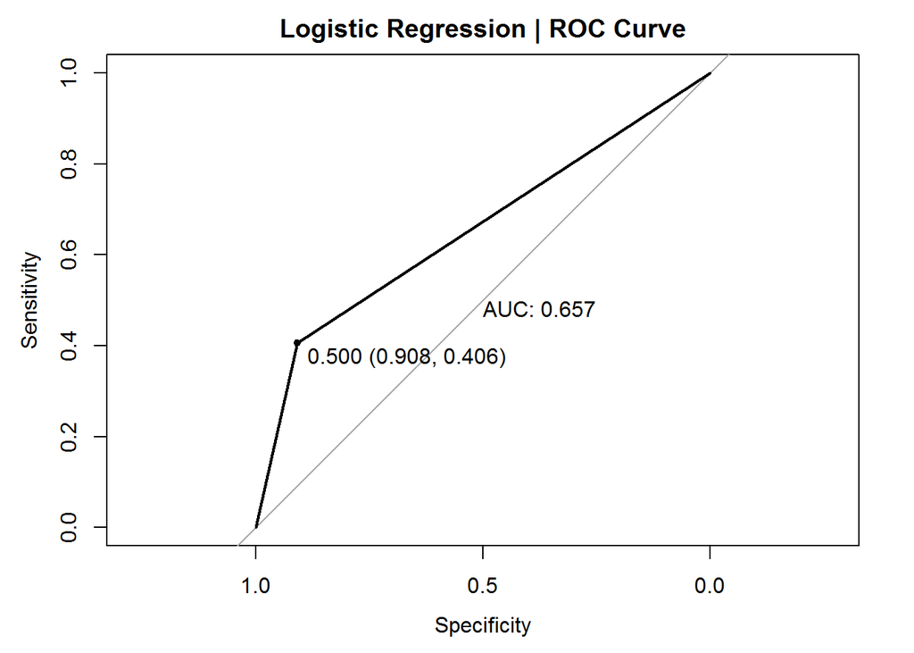

```r
plot.roc(roc1,
main="Logistic Regression | ROC Curve", percent=TRUE, of="thresholds", # compute AUC (of threshold)
thresholds="best", # select the (best) threshold
print.auc = TRUE,
print.thres="best")
```

```r
predict.lr_result <- confusionMatrix(as.factor(lr_pred_class), as.factor(test_set$TARGET_FLAG), positive = "1")
predict.lr_result
```

```
## Confusion Matrix and Statistics
##
##           Reference
## Prediction    0    1
##          0 1100  250
##          1  112  171
##
##                Accuracy : 0.7783
##                  95% CI : (0.7574, 0.7983)
##     No Information Rate : 0.7422
##     P-Value [Acc > NIR] : 0.0003916
##
##                   Kappa : 0.3513
##
##  Mcnemar's Test P-Value : 5.997e-13
##
##             Sensitivity : 0.4062
##             Specificity : 0.9076
##          Pos Pred Value : 0.6042
##          Neg Pred Value : 0.8148
##              Prevalence : 0.2578
##          Detection Rate : 0.1047
##    Detection Prevalence : 0.1733
##       Balanced Accuracy : 0.6569
##
##        'Positive' Class : 1
##
```

# KNN model

```r
trainData1 = training[,-c(1,2)]
testData1 = test_set[,-c(1,2)]

train_lbls <- training$TARGET_FLAG
test_lbls <- test_set$TARGET_FLAG

knn_model <- knn(train = trainData1, test = testData1, cl= train_lbls,k = 7, prob = TRUE)

roc2 <- roc(test_set$TARGET_FLAG, attributes(knn_model)$prob)
roc2$auc
```

```
## Area under the curve: 0.618
```

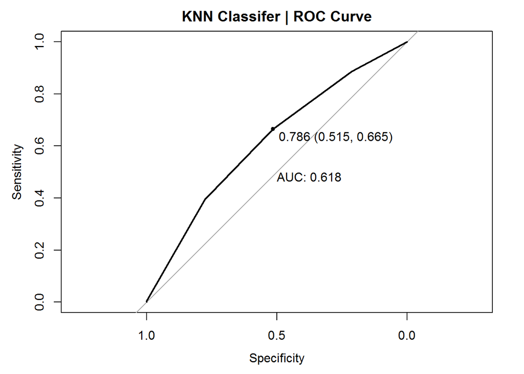

```r
plot.roc(roc2,
main="KNN Classifer | ROC Curve", percent=TRUE, of="thresholds", # compute AUC (of threshold)
thresholds="best", # select the (best) threshold
print.auc = TRUE,
print.thres="best")
```

```r
predict.knn_result <- confusionMatrix(knn_model, as.factor(test_set$TARGET_FLAG), positive = "1")
predict.knn_result
```

```
## Confusion Matrix and Statistics
##
##           Reference
## Prediction    0    1
##          0 1092  329
##          1  120   92
##
##                Accuracy : 0.725
##                  95% CI : (0.7027, 0.7466)
##     No Information Rate : 0.7422
##     P-Value [Acc > NIR] : 0.9458
##
##                   Kappa : 0.1426
##
##  Mcnemar's Test P-Value : <2e-16
##
##             Sensitivity : 0.21853
##             Specificity : 0.90099
##          Pos Pred Value : 0.43396
##          Neg Pred Value : 0.76847
##              Prevalence : 0.25781
##          Detection Rate : 0.05634
##    Detection Prevalence : 0.12982
##       Balanced Accuracy : 0.55976
##
##        'Positive' Class : 1
##
```

# Naive Bayes

```r
library(e1071)

nb_model=naiveBayes(as.factor(TARGET_FLAG) ~ ., data=training[,-2])

nm_pred_prob=predict(nb_model,newdata = test_set, type =  "raw" )
nm_pred_class=predict(nb_model,newdata = test_set, type ="class")

roc3 <- roc(as.factor(test_set$TARGET_FLAG), nm_pred_prob[,2])
roc3$auc
```

```
## Area under the curve: 0.7757
```

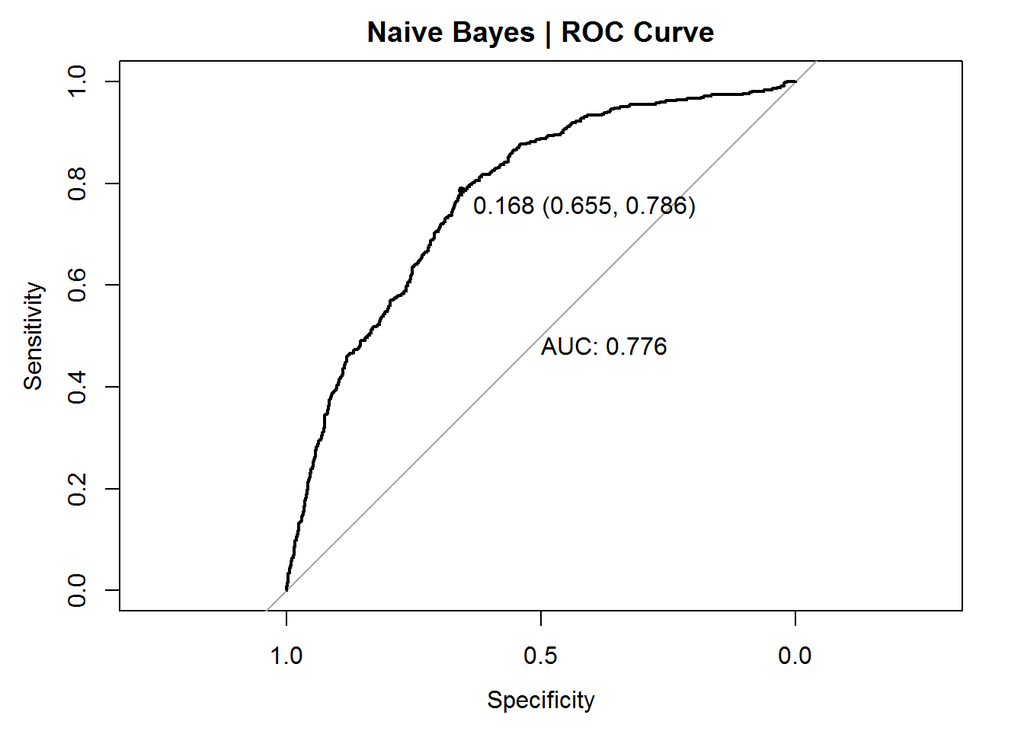

```r
plot.roc(roc3,
main="Naive Bayes | ROC Curve", percent=TRUE, of="thresholds", # compute AUC (of threshold)
thresholds="best", # select the (best) threshold
print.auc = TRUE,
print.thres="best")
```

```r
predict.nb_result <- confusionMatrix(nm_pred_class, as.factor(test_set$TARGET_FLAG), positive = "1")
predict.nb_result
```

```
## Confusion Matrix and Statistics
##
##           Reference
## Prediction   0   1
##          0 905 151
##          1 307 270
##
##                Accuracy : 0.7195
##                  95% CI : (0.6971, 0.7412)
##     No Information Rate : 0.7422
##     P-Value [Acc > NIR] : 0.9824
##
##                   Kappa : 0.3462
##
##  Mcnemar's Test P-Value : 4.399e-13
##
##             Sensitivity : 0.6413
##             Specificity : 0.7467
##          Pos Pred Value : 0.4679
##          Neg Pred Value : 0.8570
##              Prevalence : 0.2578
##          Detection Rate : 0.1653
##    Detection Prevalence : 0.3533
##       Balanced Accuracy : 0.6940
##
##        'Positive' Class : 1
##
```

# ploting ROC of all models

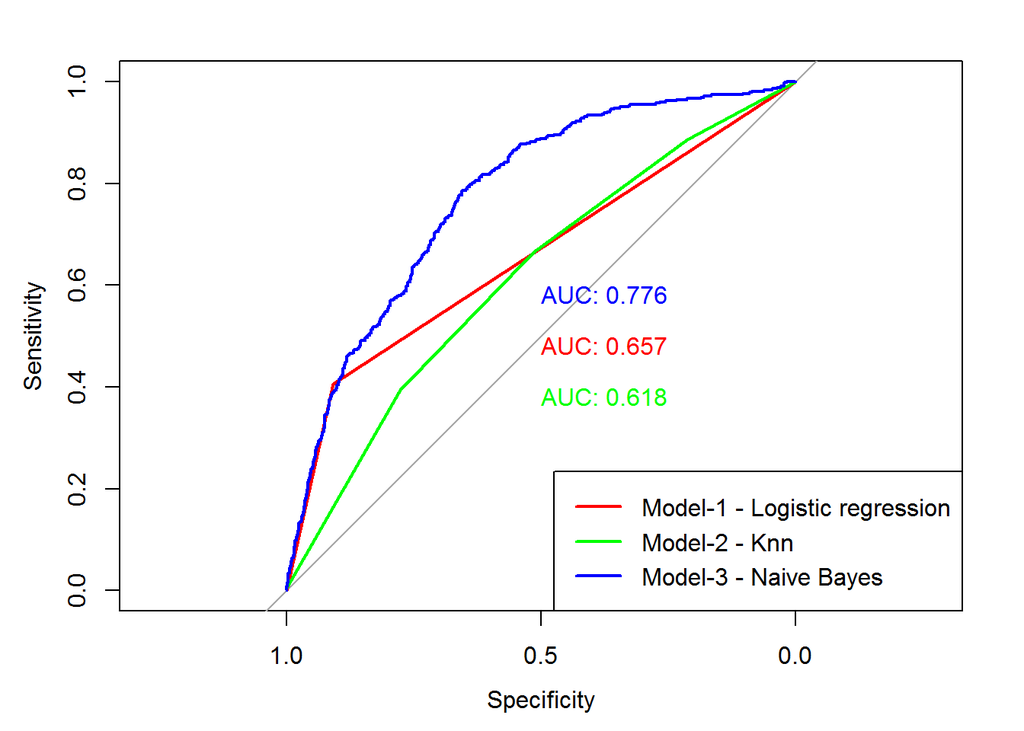

```r
plot.roc(roc1, print.auc = TRUE,
                 col = "red")
plot.roc(roc2 , add = TRUE,print.auc = TRUE,
                 col = "green", print.auc.y = .4)

plot.roc(roc3 , add = TRUE,print.auc = TRUE,
                 col = "blue", print.auc.y = .6)

legend("bottomright", legend=c("Model-1 - Logistic regression", "Model-2 - Knn", "Model-3 - Naive Bayes"),
col=c("red", "green", "blue"), lwd=2)
```

# Predicting the evaluation dataset

```r
df_classifer_pred=predict(nb_model,newdata = df_eval, type ="class")
df_eval$TARGET_FLAG <- df_classifer_pred

write.csv(df_eval, "C:\\Users\\Charls\\Documents\\CunyMSDS\\Data621\\assignments\\data621\\Data621-Assignment4\\eval_results.csv")

kable(df_eval)
```

[output not shown]